# Tipps für Übungaufgabe 8

Fabio Votta

10 Januar 2019

### Packages einladen

```r
#install.packages("pacman")
#pacman::p_install_gh("favstats/favstats")

pacman::p_load(tidyverse, magrittr, haven, sjPlot, sjmisc, sjstats, ggeffects, texreg, car, psych, knitr, BaylorEdPsych, lmtest, lme4)
```

### Datensatz einladen

```r
ess <- read_spss("../../data/esse03_mod.sav")

#binoculaR::binoculaR(ess)

# WICHTIG: zum Vergleich der Modelle sollten alle Variablen mit der selben Fallzahl geschätzt sein.
ess %<>%
  select(impcntr, lrscale, Länder) %>%
  na.omit()
```

### Abhängige Variable: Ablehnung von Migranten außerhalb Europas

*- impcntr = Allow many/few immigrants from poorer countries outside Europe*

Multilevel-Modelle lassen sich in R mit Hilfe des `lme4` packages sehr einfach spezifizieren. Zunächst testen wir ein Nullmodell auf folgende Art und Weise.

```r
mod0 <- lmer(impcntr ~ 1 + (1 | Länder), data = ess)
```

Die Syntax ist sehr ähnlich zur üblichen OLS. Die 1 stehen jeweils für Platzhalter, da wir keine unabhängigen Variablen spezifizieren. Das einzig wirklich neue ist dieser Part `(1 | Länder)`. Hier wird der *random* Part der Gleichung spezifiziert. Die 1 steht für jeglichen *random slope* (wenn man einen spezifizieren möchte) und der Teil nach dem `|` steht für den *random intercept* bzw. der Kontext über den unser Modell variieren soll. Dieser Part ist demnach natürlich absolut wichtig um ein Multilevel-Modell zu schätzen, ohne Kontext (Länder, Zeit etc.) kein Mehrebenenmodell!

Die Regressionstabellen Funktionen (`screenreg`, `htmlreg` und `texreg`) können auch hier ganz einfach auf das Modell-Objekt angewandet werden.

```r
texreg::htmlreg(mod0)
```

Statistical models

|  | **Model 1** |  |
| --- | --- | --- |
| (Intercept) | 2.54*** |  |
|  | (0.07) |  |
| AIC | 44735.08 |  |
| BIC | 44758.42 |  |
| Log Likelihood | -22364.54 |  |
| Num. obs. | 17681 |  |
| Num. groups: Länder | 26 |  |
| Var: Länder (Intercept) | 0.13 |  |
| Var: Residual | 0.73 |  |
| p < 0.001, p < 0.01, p < 0.05 |  |  |

Angezeigt wird natürlich nur der Intercept, da wir keine UV spezifiziert haben. Unter `Var: Länder (Intercept)` wird die Varianz des random intercepts gezeigt (Level 2 oder Zwischen-Gruppen Varianz) und unter `Var: Residual` findet sich die Varianz des Level 1 Fehlers (oder In-Group Varianz).

Die Werte für `AIC` and `BIC` sind Gütemaße. Umso kleiner der Wert, desto besser passt das Modell auf die Daten.

Das Tolle an den Tabellenfunktionen von `texreg` ist, dass wir die Tabelle anpassen können:

```r
htmlreg(mod0,                               #Regressionsobjekte
        custom.model.names = c("Nullmodel"),  #Benenne die Modelle
        custom.coef.names = c("Intercept"), #Benenne die Koeffienten
        custom.gof.names = c("AIC","BIC",   #Benenne die fit Statistik
                               "Log Likelihood","Observationen",
                               "Länder","Zwischen-Gruppen Varianz",
                               "In-Group Varianz"))
```

Statistical models

|  | **Nullmodel** |  |
| --- | --- | --- |
| Intercept | 2.54*** |  |
|  | (0.07) |  |
| AIC | 44735.08 |  |
| BIC | 44758.42 |  |
| Log Likelihood | -22364.54 |  |
| Observationen | 17681 |  |
| Länder | 26 |  |
| Zwischen-Gruppen Varianz | 0.13 |  |
| In-Group Varianz | 0.73 |  |
| p < 0.001, p < 0.01, p < 0.05 |  |  |

Wir können nun den Intraklassenkoeffizient per Hand ausrechnen:

```r
icc(mod0)
```

```
##
## Intraclass Correlation Coefficient for Linear mixed model
##
## Family : gaussian (identity)
## Formula: impcntr ~ 1 + (1 | Länder)
##
##   ICC (Länder): 0.1465
```

Der ICC sagt aus, dass 14.66% der Varianz von Ablehnung von Migranten außerhalb Europas auf Länderebene liegt. Dadurch übeschreitet diese die Multilevel-Daumenregel von mindestens 10% Varianz auf der 2. Ebene.

Wir können den *random intercept* des Modells auch sehr einfach visualisieren:

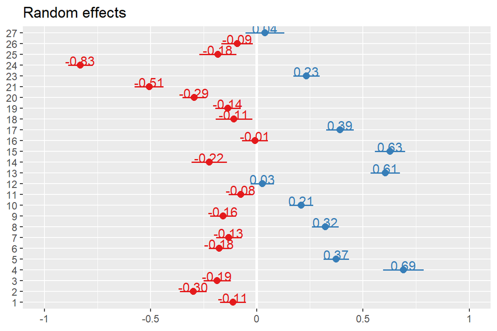

```r
plot_model(mod0, type = "re", sort.est = T, show.values = T, show.p = T, value.offset = 0.4)
```

Der Forest Plot zeigt die jeweiligen Abweichungen der Länder vom *grand mean*.

**Mehr Details über ein Modell**

```r
summary(mod0)
```

```
## Linear mixed model fit by REML ['lmerMod']
## Formula: impcntr ~ 1 + (1 | Länder)
##    Data: ess
##
## REML criterion at convergence: 44729.1
##
## Scaled residuals:
##     Min      1Q  Median      3Q     Max
## -2.6126 -0.5469 -0.1728  0.7209  2.6775
##
## Random effects:
##  Groups   Name        Variance Std.Dev.
##  Länder   (Intercept) 0.1253   0.3540
##  Residual             0.7297   0.8542
## Number of obs: 17681, groups:  Länder, 26
##
## Fixed effects:
##             Estimate Std. Error t value
## (Intercept)  2.54246    0.06975   36.45
```

## Nun fügen wir eine x-Variable hinzu: Links-Rechts Skala

*- lrscale = Placement on left right scale*

Das funktioniert genau so wie wir es aus der linearen Regression kennen.

```r
mod1 <- lme4::lmer(impcntr ~ lrscale + (1 | Länder), data = ess)

htmlreg(list(mod0, mod1),                               #Regressionsobjekte
        custom.model.names = c("Nullmodel","Model 1"),  #Benenne die Modelle
        custom.coef.names = c("Intercept","Links-Rechts Skala"), #Benenne die Koeffienten
        custom.gof.names = c("AIC","BIC",                #Benenne die fit Statistik
                               "Log Likelihood","Observationen",
                               "Länder","Zwischen-Gruppen Varianz",
                               "In-Group Varianz"))
```

Statistical models

|  | **Nullmodel** | **Model 1** |  |
| --- | --- | --- | --- |
| Intercept | 2.54*** | 2.26*** |  |
|  | (0.07) | (0.07) |  |
| Links-Rechts Skala |  | 0.05*** |  |
|  |  | (0.00) |  |
| AIC | 44735.08 | 44434.76 |  |
| BIC | 44758.42 | 44465.88 |  |
| Log Likelihood | -22364.54 | -22213.38 |  |
| Observationen | 17681 | 17681 |  |
| Länder | 26 | 26 |  |
| Zwischen-Gruppen Varianz | 0.13 | 0.12 |  |
| In-Group Varianz | 0.73 | 0.72 |  |
| p < 0.001, p < 0.01, p < 0.05 |  |  |  |

*Wenn die beiden Modelle aufeinander aufbauen, dann vergleicht ein `Likelihood Ratio Test` die beiden Modelle. Weichen die Devianzwerte signifkant voneinander ab, dann kann das komplexere Modell angenommen werden. Hier führen wir den LRT mit der `anova` Funktion durch.*

```r
anova(mod1, mod0)
```

```
## Data: ess
## Models:
## mod0: impcntr ~ 1 + (1 | Länder)
## mod1: impcntr ~ lrscale + (1 | Länder)
##      Df   AIC   BIC logLik deviance  Chisq Chi Df            Pr(>Chisq)
## mod0  3 44732 44755 -22363    44726
## mod1  4 44422 44453 -22207    44414 312.06      1 < 0.00000000000000022
##
## mod0
## mod1 ***
## ---
## Signif. codes:  0 '***' 0.001 '**' 0.01 '*' 0.05 '.' 0.1 ' ' 1
```

Die Ergebnisse des LRT zeigen, dass die Devianz im komplexeren Modell signifikant von der im Nullmodell abweicht, damit kann Modell 1 angenommen werden.

> **ACHTUNG:** Der Modellvergleich muss immer mit einer ML Schätzung stattfinden. Die `anova` Funktion refitted das Modell glücklicherweise automatisch. Um die Koeffizienten zu interpretieren wird ein REML Modell geschätzt.

## Random Slope Modell

*Im nächsten Schritt können wir noch die unabhängige Variable `lrscale` random setzen und über die Länder variieren lassen.*

Um den random slope zu spezifizieren, setzen wir einfach unsere gewünschte UV statt der 1 in dem random Part der Formel ein.

```r
mod2 <- lme4::lmer(impcntr ~ lrscale + (lrscale | Länder), data = ess)

htmlreg(list(mod0, mod1, mod2),                               #Regressionsobjekte
        custom.model.names = c("Nullmodell","Modell 1", "Modell 2"),  #Benenne die Modelle
        custom.coef.names = c("Intercept","Links-Rechts Skala"), #Benenne die Koeffienten
        custom.gof.names = c("AIC","BIC",                #Benenne die fit Statistik
                               "Log Likelihood","Observationen",
                               "Länder","Zwischen-Gruppen Varianz",
                               "In-Group Varianz",
                             "Varianz: Links-Rechts Skala",
                             "Kovarianz: Intercept - Links-Rechts Skala"))
```

Statistical models

|  | **Nullmodell** | **Modell 1** | **Modell 2** |  |
| --- | --- | --- | --- | --- |
| Intercept | 2.54*** | 2.26*** | 2.28*** |  |
|  | (0.07) | (0.07) | (0.09) |  |
| Links-Rechts Skala |  | 0.05*** | 0.05*** |  |
|  |  | (0.00) | (0.01) |  |
| AIC | 44735.08 | 44434.76 | 44250.68 |  |
| BIC | 44758.42 | 44465.88 | 44297.36 |  |
| Log Likelihood | -22364.54 | -22213.38 | -22119.34 |  |
| Observationen | 17681 | 17681 | 17681 |  |
| Länder | 26 | 26 | 26 |  |
| Zwischen-Gruppen Varianz | 0.13 | 0.12 | 0.21 |  |
| In-Group Varianz | 0.73 | 0.72 | 0.71 |  |
| Varianz: Links-Rechts Skala |  |  | 0.00 |  |
| Kovarianz: Intercept - Links-Rechts Skala |  |  | -0.01 |  |
| p < 0.001, p < 0.01, p < 0.05 |  |  |  |  |

Mit der `anova` Funktionen können wir wieder feststellen ob es signifikante Abweichungen gibt:

```r
anova(mod2,mod1)
```

```
## Data: ess
## Models:
## mod1: impcntr ~ lrscale + (1 | Länder)
## mod2: impcntr ~ lrscale + (lrscale | Länder)
##      Df   AIC   BIC logLik deviance  Chisq Chi Df            Pr(>Chisq)
## mod1  4 44422 44453 -22207    44414
## mod2  6 44240 44286 -22114    44228 185.74      2 < 0.00000000000000022
##
## mod1
## mod2 ***
## ---
## Signif. codes:  0 '***' 0.001 '**' 0.01 '*' 0.05 '.' 0.1 ' ' 1
```

In der Tat erhalten wir durch spezifizieren eines random slope Modells einen besseren Fit. Damit können wir Modell 2 annehmen.

Zusätzlich zu den bekannten Gütemessungen im unteren Teil der Tabelle befindet sich jetzt noch die Varianz des `random slopes` so wie die Kovarianz zwischen dem Intercept und dem random slope. Letzteres zeigt uns an, dass es einen negativen Zusammenhang gibt zwischen den random intercepts und der Links-Rechts Skala (Kovarianz = -0.01). Diese Kovarianz zeigt, dass umso höher die *group mean* Ablehnung in einem Land ist, desto rechter sind die Menschen. Das macht inhaltlich auf jedenfall Sinn.

**Zum Schluss noch ein paar Visualisierungen der random und fixed effects:**

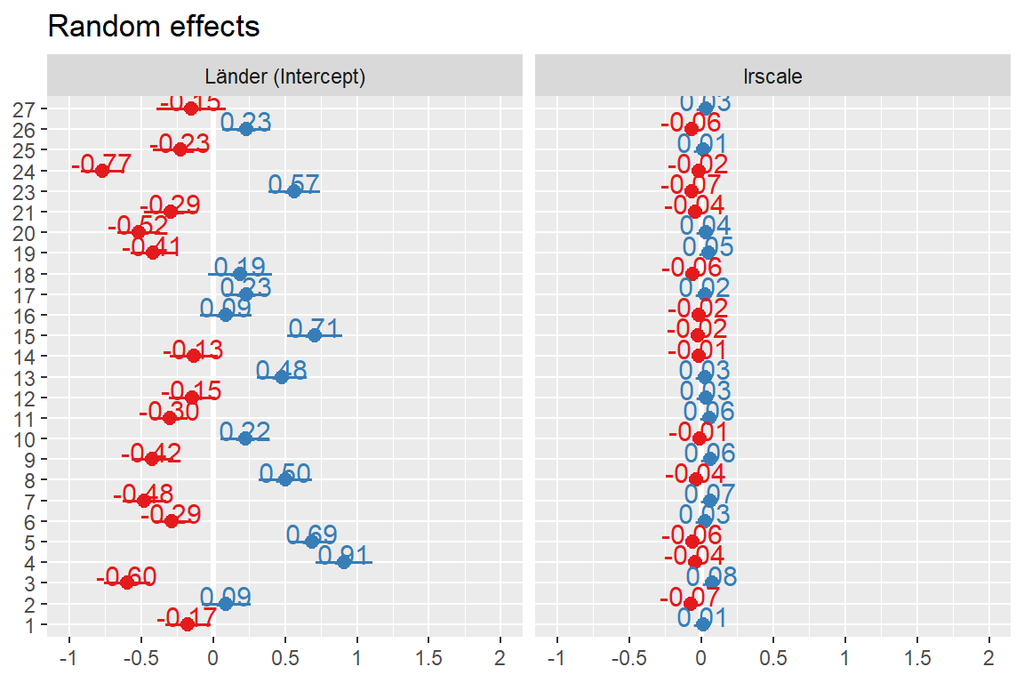

```r
plot_model(mod2, type = "re", sort.est = T, show.values = T, show.p = T, value.offset = 0.4)
```

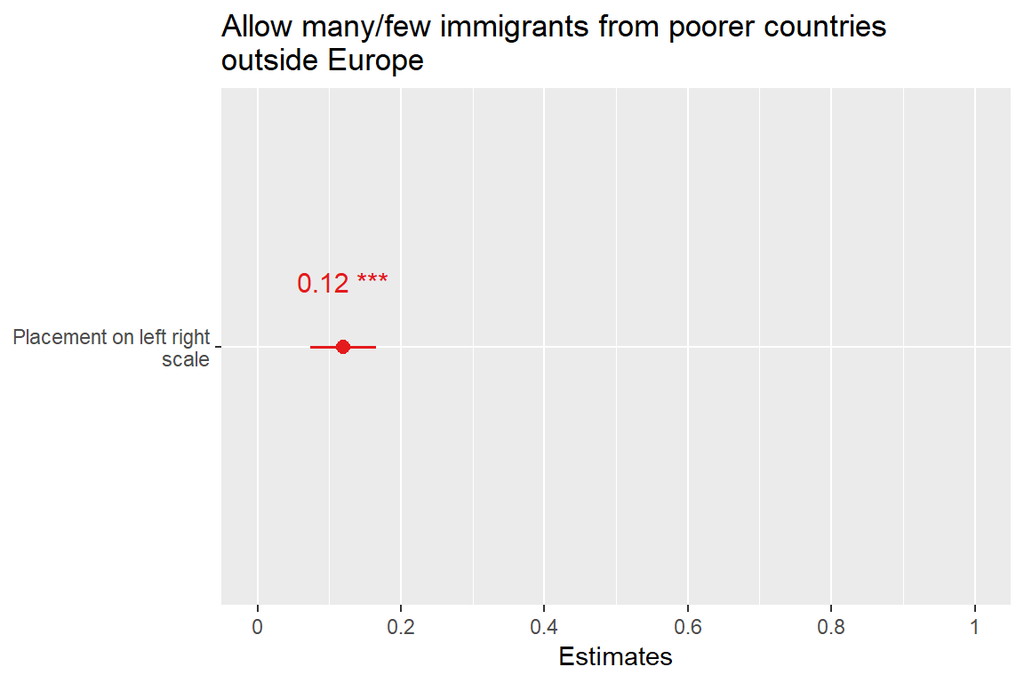

```r
plot_model(mod2, type = "std", sort.est = T, show.values = T, show.p = T)
```

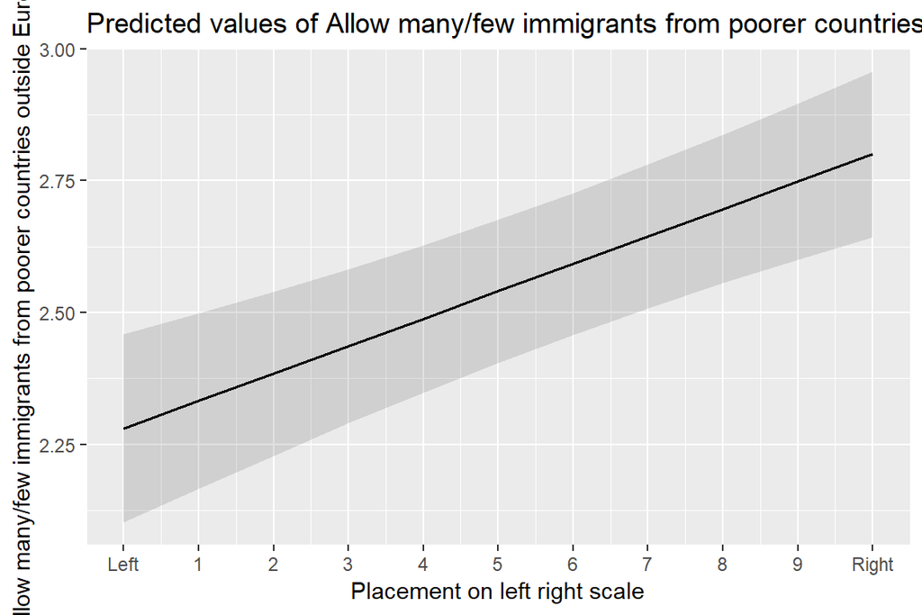

```r
plot_model(mod2, terms = "lrscale", type = "pred", sort.est = T, show.values = T, show.p = T)
```

```r
plot_model(mod2, type = "diag", facet.grid = F, y.offset = 0.55)
```

[[1]]

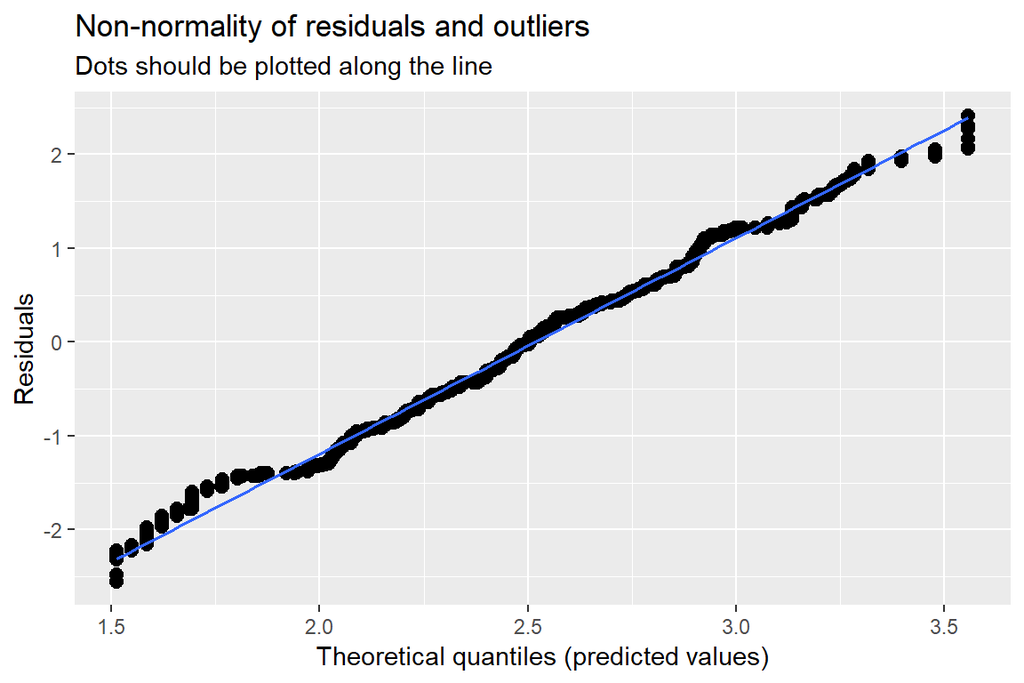

[[2]] [[2]]$Länder

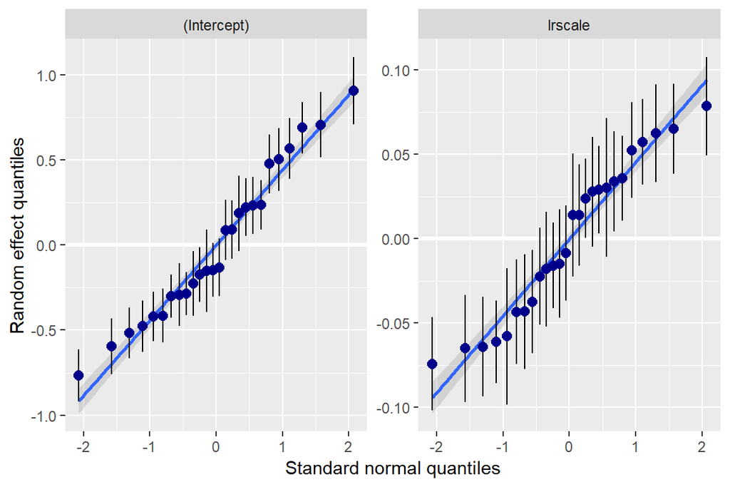

[[3]]

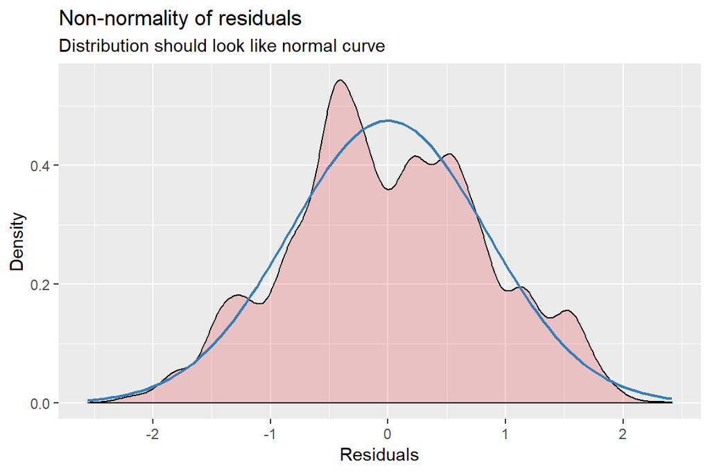

[[4]]

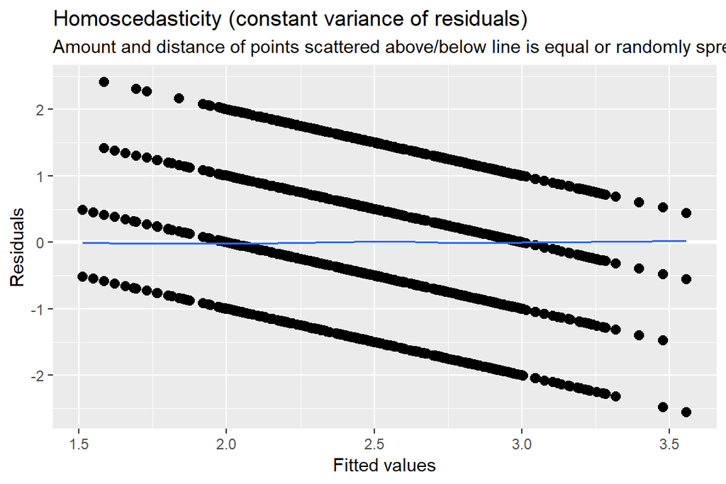